# CRC-EAA-Classifier

## Preliminary Steps

#### Loading libraries

```r
library(lme4)
library(glmnet)
library(performance)
library(ggplot2)
library(ggpubr)
library(caret)
library(pheatmap)
library(PRROC)
library(pROC)
library(data.table)
```

Setting working directory

```r
setwd("~/your/working/directory/")
```

#### Loading the data

Read the dataset in .csv format. It contains epigenetic ages and epigentic age differences.

| sampleID | patientID | race | sex | age | tissue | site | Array | Slide | datasetID | platformID | Horvath | Hannum | Pheno | SkinBlood | PedBE | Wu | Zhang_BLUP | Zhang_EN | tnsc | irS | irT | EpiTOC | HypoScore | MiAge | HorvathAAd | HannumAAd | PhenoAAd | SkinBloodAAd | PedBEAAd | … |
| --- | --- | --- | --- | --- | --- | --- | --- | --- | --- | --- | --- | --- | --- | --- | --- | --- | --- | --- | --- | --- | --- | --- | --- | --- | --- | --- | --- | --- | --- | --- |
| 10N | 10_EMTAB3027 | mixed | M | 63.0 | normal | Left | R05C02 | 8963303147 | E-MTAB-3027 | GPL13534 | 70.28731 | 76.67774 | 68.906610 | 71.52727 | 12.513987 | 10.16357338 | 72.99702 | 77.11250 | 5686.8750 | 90.26786 | 149.83956 | 0.13836788 | 0.8684559 | 1389.62898 | 7.287313868 | 13.67773645 | 5.90661048 | 8.52726876 | -50.48601 | … |
| 10T | 10_EMTAB3027 | mixed | M | 63.0 | tumour | Left | R06C02 | 8963303147 | E-MTAB-3027 | GPL13534 | 72.60179 | 83.11846 | 74.703968 | 73.27088 | 15.317213 | 11.92290372 | 74.59397 | 77.38619 | 4713.8911 | 74.82367 | 149.83956 | 0.11336855 | 0.8743871 | 1773.68279 | 9.601792672 | 20.11846355 | 11.70396801 | 10.27088040 | -47.68279 | … |
| 11N | 11_EMTAB3027 | white | M | 84.0 | normal | Right | R01C01 | 8769527109 | E-MTAB-3027 | GPL13534 | 80.77493 | 85.30843 | 86.326948 | 83.38305 | 14.317180 | 11.32146067 | 83.17976 | 87.59979 | 8042.8998 | 95.74881 | 149.83956 | 0.17841267 | 0.8802586 | 2084.33343 | -3.225068821 | 1.30843452 | 2.32694798 | -0.61695325 | -69.68282 | … |
| 11T | 11_EMTAB3027 | white | M | 84.0 | tumour | Right | R02C01 | 8769527109 | E-MTAB-3027 | GPL13534 | 67.64987 | 68.45845 | 115.944422 | 104.05921 | 18.187194 | 9.34899321 | 111.38453 | 89.94724 | 20686.2436 | 246.26481 | 149.83956 | 0.37727651 | 0.6615131 | 6588.83782 | -16.350129528 | -15.54154611 | 31.94442196 | 20.05920831 | -65.81281 | … |
| 13N | 13_EMTAB3027 | mixed | F | 46.0 | normal | Right | R03C01 | 8769527109 | E-MTAB-3027 | GPL13534 | 51.74494 | 24.44610 | 17.541189 | 37.93047 | 6.817040 | 0.21804282 | 38.00128 | 44.28956 | 930.7741 | 20.23422 | 149.83956 | 0.05082622 | 0.9077261 | 151.61531 | 5.744938372 | -21.55389974 | -28.45881113 | -8.06953013 | -39.18296 | … |
| 13T | 13_EMTAB3027 | mixed | F | 46.0 | tumour | Right | R04C01 | 8769527109 | E-MTAB-3027 | GPL13534 | 44.46772 | 64.87866 | 69.609076 | 63.71680 | 8.347334 | 9.27549858 | 68.78029 | 69.03565 | 12374.2204 | 269.00479 | 149.83956 | 0.26058853 | 0.7979034 | 3454.22729 | -1.532283090 | 18.87866147 | 23.60907572 | 17.71679993 | -37.65267 | … |
| 14N | 14_EMTAB3027 | mixed | M | 80.0 | normal | Left | R05C01 | 8769527109 | E-MTAB-3027 | GPL13534 | 81.33847 | 76.88581 | 71.310838 | 80.48328 | 15.155261 | 10.31857309 | 78.76546 | 82.38847 | 7793.3532 | 97.41691 | 149.83956 | 0.17406079 | 0.8649596 | 1844.53211 | 1.338469046 | -3.11418755 | -8.68916217 | 0.48327799 | -64.84474 | … |
| 14T | 14_EMTAB3027 | mixed | M | 80.0 | tumour | Left | R06C01 | 8769527109 | E-MTAB-3027 | GPL13534 | 70.58711 | 64.49560 | 71.657040 | 77.47834 | 14.097027 | 9.20197241 | 72.52521 | 73.31023 | 10535.0327 | 131.68791 | 149.83956 | 0.21511949 | 0.8508889 | 1681.75787 | -9.412891730 | -15.50439979 | -8.34296012 | -2.52166369 | -65.90297 | … |
| 15N | 15_EMTAB3027 | asian | M | 74.0 | normal | Left | R01C02 | 8769527109 | E-MTAB-3027 | GPL13534 | 72.98365 | 80.54321 | 72.647715 | 78.48017 | 14.404768 | 10.95758584 | 80.56529 | 83.55438 | 11434.0675 | 154.51443 | 149.83956 | 0.23397588 | 0.8624000 | 2425.69771 | -1.016346325 | 6.54321430 | -1.35228517 | 4.48017088 | -59.59523 | … |
| 15T | 15_EMTAB3027 | asian | M | 74.0 | tumour | Left | R02C02 | 8769527109 | E-MTAB-3027 | GPL13534 | 69.48722 | 82.51174 | 85.631344 | 73.61114 | 14.646673 | 11.15223859 | 81.53263 | 80.12254 | 15257.6841 | 206.18492 | 149.83956 | 0.30645463 | 0.7968455 | 3499.24788 | -4.512784810 | 8.51174192 | 11.63134380 | -0.38886328 | -59.35333 | … |

[output cut: 990 more lines]

#### Restricting the data

For the classifier development we included only samples with normal and healthy tissue status (samples labelled as “tumour” and “adenoma” were excluded). We also include only those datasets, processed from raw .idat files, i.e. we excluded datasets, for which pre-processing was not possible due to the absence of the raw data files or missing essential technical information about arrays and position of the samples on them. The ten datasets, used for the classifier are: E-MTAB-3027, E_MTAB_7036, GSE101764, GSE132804_450k, GSE132804_epic, GSE142257, GSE149282, GSE151732, GSE166212, GSE199057.

```r
ds = master_ds[master_ds$tissue %in% c("healthy", "normal"),]
all_datasets = c("E-MTAB-3027","E_MTAB_7036","GSE101764","GSE132804_450k","GSE132804_epic","GSE142257","GSE149282","GSE151732","GSE166212","GSE199057")
ds = ds[ds$datasetID %in% all_datasets,]
head(ds)
```

|  | sampleID | patientID | race | sex | age | tissue | site | Array | Slide | datasetID | platformID | Horvath | Hannum | Pheno | SkinBlood | PedBE | Wu | Zhang_BLUP | Zhang_EN | tnsc | irS | irT | EpiTOC | HypoScore | MiAge | HorvathAAd | HannumAAd | PhenoAAd | SkinBloodAAd | … |
| --- | --- | --- | --- | --- | --- | --- | --- | --- | --- | --- | --- | --- | --- | --- | --- | --- | --- | --- | --- | --- | --- | --- | --- | --- | --- | --- | --- | --- | --- | --- |
| 1 | 10N | 10_EMTAB3027 | mixed | M | 63 | normal | Left | R05C02 | 8963303147 | E-MTAB-3027 | GPL13534 | 70.28731 | 76.67774 | 68.90661 | 71.52727 | 12.51399 | 10.1635734 | 72.99702 | 77.11250 | 5686.8750 | 90.26786 | 149.8396 | 0.13836788 | 0.8684559 | 1389.6290 | 7.287314 | 13.677736 | 5.906610 | 8.5272688 | … |
| 3 | 11N | 11_EMTAB3027 | white | M | 84 | normal | Right | R01C01 | 8769527109 | E-MTAB-3027 | GPL13534 | 80.77493 | 85.30843 | 86.32695 | 83.38305 | 14.31718 | 11.3214607 | 83.17976 | 87.59979 | 8042.8998 | 95.74881 | 149.8396 | 0.17841267 | 0.8802586 | 2084.3334 | -3.225069 | 1.308435 | 2.326948 | -0.6169533 | … |
| 5 | 13N | 13_EMTAB3027 | mixed | F | 46 | normal | Right | R03C01 | 8769527109 | E-MTAB-3027 | GPL13534 | 51.74494 | 24.44610 | 17.54119 | 37.93047 | 6.81704 | 0.2180428 | 38.00128 | 44.28956 | 930.7741 | 20.23422 | 149.8396 | 0.05082622 | 0.9077261 | 151.6153 | 5.744938 | -21.553900 | -28.458811 | -8.0695301 | … |
| 7 | 14N | 14_EMTAB3027 | mixed | M | 80 | normal | Left | R05C01 | 8769527109 | E-MTAB-3027 | GPL13534 | 81.33847 | 76.88581 | 71.31084 | 80.48328 | 15.15526 | 10.3185731 | 78.76546 | 82.38847 | 7793.3532 | 97.41691 | 149.8396 | 0.17406079 | 0.8649596 | 1844.5321 | 1.338469 | -3.114188 | -8.689162 | 0.4832780 | … |
| 9 | 15N | 15_EMTAB3027 | asian | M | 74 | normal | Left | R01C02 | 8769527109 | E-MTAB-3027 | GPL13534 | 72.98365 | 80.54321 | 72.64771 | 78.48017 | 14.40477 | 10.9575858 | 80.56529 | 83.55438 | 11434.0675 | 154.51443 | 149.8396 | 0.23397588 | 0.8624000 | 2425.6977 | -1.016346 | 6.543214 | -1.352285 | 4.4801709 | … |
| 11 | 16N | 16_EMTAB3027 | white | M | 76 | normal | Right | R01C02 | 8963303147 | E-MTAB-3027 | GPL13534 | 68.83245 | 77.08762 | 69.36958 | 70.99314 | 13.35829 | 9.0506712 | 75.67190 | 79.14071 | 7151.9311 | 94.10436 | 149.8396 | 0.16155429 | 0.8478822 | 1769.3102 | -7.167552 | 1.087616 | -6.630423 | -5.0068563 | … |

#### Removing outliers

We performed the analysis of outliers using the differences between epigenetic and chronological age values, which we denote as EAAd. This metric was only calculated for the first and second generation clocks, and not for the mitotic clocks. A sample was labelled as an outlier if its EAAd value was outside of the three standard deviations window from the mean EAAd across the dataset.

```r
clocks = c("Horvath","Hannum","Pheno","SkinBlood","PedBE","Wu","Zhang_BLUP","Zhang_EN")
age_diff = c("HorvathAAd","HannumAAd","PhenoAAd","SkinBloodAAd","PedBEAAd","WuAAd","Zhang_BLUPAAd","Zhang_ENAAd")
outliers_ds = ds[,c("sampleID","patientID",age_diff)]
clock_means = colMeans(ds[age_diff])
clock_sds = apply(ds[,age_diff],2,sd)
n_range_min = clock_means-3*clock_sds
n_range_max = clock_means+3*clock_sds

print("Range of the clocks without outliers")
```

```
[1] "Range of the clocks without outliers"
```

```r
cbind(n_range_min, n_range_max) # display the range of the epigenetic ages afetr removing the ouliers
```

```
              n_range_min n_range_max
HorvathAAd      -15.16708    21.08732
HannumAAd       -31.51617    41.67630
PhenoAAd        -33.65557    40.87699
SkinBloodAAd    -12.13660    32.10932
PedBEAAd        -75.78678   -17.19055
WuAAd           -81.34404   -17.03888
Zhang_BLUPAAd   -13.17326    38.41281
Zhang_ENAAd      -8.47212    38.50799
```

Identify the number of outlying samples for each clock

```r
for(a in age_diff){outliers_ds[a] = (outliers_ds[a]<n_range_max[a] & outliers_ds[a]>n_range_min[a])}
outliers_count = rowSums(!(outliers_ds[,-c(1,2)]))
outliers_count_clock = colSums(!(outliers_ds[,-c(1,2)]))
print("Number of outliers by number of clocks")
```

```
[1] "Number of outliers by number of clocks"
```

```r
table(outliers_count)
```

```
outliers_count
  0   1   2   3   4   5
990  18  10   4   4   3
```

```r
print("Number of outliers by clock")
```

```
[1] "Number of outliers by clock"
```

```r
outliers_count_clock
```

```
   HorvathAAd     HannumAAd      PhenoAAd  SkinBloodAAd      PedBEAAd         WuAAd Zhang_BLUPAAd   Zhang_ENAAd
            9            14            18             9             6             4            14             7
```

We removed all the samples, which are outliers in at least one clock. In total, 39 samples were removed as outliers.

```r
outlier_samples = outliers_ds$sampleID[outliers_count>=1]
print("Outliers sample IDs")
```

```
[1] "Outliers sample IDs"
```

```r
outlier_samples
```

```
 [1] "48N"        "CG268.N"    "CG284.N"    "G1266.N"    "GSM2714593" "GSM2714647" "GSM2714648" "GSM2714682" "GSM2714761" "GSM3892403" "GSM3892406"
[12] "GSM3892419" "GSM3892502" "GSM3892510" "GSM3892531" "GSM3892596" "GSM3892612" "GSM3892646" "GSM3892702" "GSM3892715" "GSM4495514" "GSM4589253"
[23] "GSM4589342" "GSM4589365" "GSM4589454" "GSM5065988" "GSM5963201" "GSM5963204" "GSM5963208" "GSM5963210" "GSM5963240" "GSM5963251" "GSM5963260"
[34] "GSM5963264" "GSM5963265" "GSM5963266" "GSM5963267" "GSM5963274" "GSM5963280"
```

```r
ds_filtered = ds[-which(ds$sampleID %in% outlier_samples),]
```

## Classifier

### Preparing the data: Defining train and test datasets

We build classifier using 990 samples from ten studies, out of them 328 are normal colon mucosa samples from CRC patients, and 662 colon mucosa samples came from the non-cancerous individuals. Table with distribution of of samples across the studies are given in Table below.

```r
table(ds_filtered$datasetID,ds_filtered$tissue)
```

```
                 healthy normal
  E_MTAB_7036          0     24
  E-MTAB-3027          0     22
  GSE101764            0    140
  GSE132804_450k      73     17
  GSE132804_epic     150     44
  GSE142257          118      0
  GSE149282            0      9
  GSE151732          250      0
  GSE166212            0      5
  GSE199057           71     67
```

```r
print(paste("In total we have ",sum(ds_filtered$tissue=="normal")," normal samples and ",sum(ds_filtered$tissue=="healthy"), " healthy samples.",sep="" ))
```

```
[1] "In total we have 328 normal samples and 662 healthy samples."
```

The dataset was split into train and test set. The train set consists of datasets from six studies (341/215 healthy/normal samples), and test set includes four datasets (321/113 healthy/normal samples). The choice of not using samples from one study in train and test subsets was made to avoid potential data leak.

```r
datasets_test = c("E_MTAB_7036","E-MTAB-3027","GSE199057","GSE151732") # testing data
datasets_train = c("GSE101764","GSE132804_epic","GSE149282","GSE132804_450k","GSE142257","GSE166212") # training data

data_test = ds_filtered[which(ds_filtered$datasetID %in% datasets_test),]
data_train = ds_filtered[which(ds_filtered$datasetID %in% datasets_train),]

print("####################### TRAIN DATA ######################")
```

```
[1] "####################### TRAIN DATA ######################"
```

```r
print("Train datasets:")
```

```
[1] "Train datasets:"
```

```r
datasets_train
```

```
[1] "GSE101764"      "GSE132804_epic" "GSE149282"      "GSE132804_450k" "GSE142257"      "GSE166212"
```

```r
table(data_train$datasetID, data_train$tissue)
```

```
                 healthy normal
  GSE101764            0    140
  GSE132804_450k      73     17
  GSE132804_epic     150     44
  GSE142257          118      0
  GSE149282            0      9
  GSE166212            0      5
```

```r
table(data_train$tissue)
```

```
healthy  normal
    341     215
```

```r
print("####################### TEST DATA ######################")
```

```
[1] "####################### TEST DATA ######################"
```

```r
print("Test datasets:")
```

```
[1] "Test datasets:"
```

```r
datasets_test
```

```
[1] "E_MTAB_7036" "E-MTAB-3027" "GSE199057"   "GSE151732"
```

```r
table(data_test$datasetID, data_test$tissue)
```

```
              healthy normal
  E_MTAB_7036       0     24
  E-MTAB-3027       0     22
  GSE151732       250      0
  GSE199057        71     67
```

```r
table(data_test$tissue)
```

```
healthy  normal
    321     113
```

```r
data_train$sex[data_train$sex=="M"]=1
data_train$sex[data_train$sex=="F"]=0
data_train$sex = as.numeric(data_train$sex)

data_test$sex[data_test$sex=="M"]=1
data_test$sex[data_test$sex=="F"]=0
data_test$sex = as.numeric(data_test$sex)
```

### Grid Search

#### Data preparation

We manually created folds for cross-validation. It was done by choosing two datasets for each test, and 4 for train. We ensured that at every fold test data contain both healthy and normal samples. Due to only three (out of six) datasets containing healthy samples, we included all possibles pairs of them with each other and normal-only datasets, which makes 12 folds (5+4+3).

```r
folds_test = list(c("GSE132804_450k","GSE132804_epic"),c("GSE132804_450k","GSE142257"),c("GSE132804_450k","GSE149282"),c("GSE132804_450k","GSE166212"),c("GSE132804_450k","GSE101764"),c("GSE132804_epic","GSE142257"),c("GSE132804_epic","GSE149282"),c("GSE132804_epic","GSE166212"),c("GSE132804_epic","GSE101764"),c("GSE101764","GSE142257"),c("GSE142257","GSE149282"),c("GSE142257","GSE166212"))

folds_train = list(setdiff(datasets_train,c("GSE132804_450k","GSE132804_epic")),setdiff(datasets_train,c("GSE132804_450k","GSE142257")),setdiff(datasets_train,c("GSE132804_450k","GSE149282")),setdiff(datasets_train,c("GSE132804_450k","GSE166212")),setdiff(datasets_train,c("GSE132804_450k","GSE101764")),setdiff(datasets_train,c("GSE132804_epic","GSE142257")),setdiff(datasets_train,c("GSE132804_epic","GSE149282")),setdiff(datasets_train,c("GSE132804_epic","GSE166212")),setdiff(datasets_train,c("GSE132804_epic","GSE101764")),setdiff(datasets_train,c("GSE101764","GSE142257")),setdiff(datasets_train,c("GSE142257","GSE149282")),setdiff(datasets_train,c("GSE142257","GSE166212")))
```

#### Cross-validation

We perform cross-validation to identify optimal values of the elastic net parameters alpha and lambda. At each step of cross-validation (i.e. for each value of alpha and lambda at every fold) we calculate the residuals and scale the data using standard normal distribution, and fit the elastic net. We calculate ROC-AUC, and PR-AUC metrics.

|  | fold | alpha | lambda | n_train | n_train_normal | n_train_healthy | n_test | n_test_normal | n_test_healthy | roc_auc | pr_auc | N_predictors |
| --- | --- | --- | --- | --- | --- | --- | --- | --- | --- | --- | --- | --- |
| 1 | 1 | 0 | 0.00 | 272 | 154 | 118 | 284 | 61 | 223 | 0.5048519 | 0.2197739 | 12 |
| 2 | 1 | 0 | 0.01 | 272 | 154 | 118 | 284 | 61 | 223 | 0.5066529 | 0.2215641 | 12 |
| 3 | 1 | 0 | 0.02 | 272 | 154 | 118 | 284 | 61 | 223 | 0.5145924 | 0.2230545 | 12 |
| 4 | 1 | 0 | 0.03 | 272 | 154 | 118 | 284 | 61 | 223 | 0.5198118 | 0.2270448 | 12 |
| 5 | 1 | 0 | 0.04 | 272 | 154 | 118 | 284 | 61 | 223 | 0.5229729 | 0.2296485 | 12 |
| 6 | 1 | 0 | 0.05 | 272 | 154 | 118 | 284 | 61 | 223 | 0.5244431 | 0.2299474 | 12 |

We calculate means and SDs for ROC-AUC and PR-AUC for each pair of parameters alpha and lambda from cross-validation results.

```r
# Means
res_mean = c("alpha","lambda","roc","pr","n_predictors")
for(i in unique(res$alpha))
{
  for(j in unique(res$lambda))
{
    roc_auc_mean = mean(as.numeric(res$roc_auc[res$alpha==i & res$lambda==j]))
    pr_auc_mean = mean(as.numeric(res$pr_auc[res$alpha==i & res$lambda==j]))
    n_predictors_mean = mean(as.numeric(res$N_predictors[res$alpha==i & res$lambda==j]))
  res_mean = rbind(res_mean,c(i,j,roc_auc_mean,pr_auc_mean,n_predictors_mean))
  }}
colnames(res_mean) = res_mean[1,]
res_mean = as.data.frame(res_mean[-1,])
```

```r
# SDs
res_sd = c("alpha","lambda","roc","pr","n_predictors")
for(i in unique(res$alpha))
{
  for(j in unique(res$lambda))
{
    roc_auc_sd = sd(as.numeric(res$roc_auc[res$alpha==i & res$lambda==j]))
    pr_auc_sd = sd(as.numeric(res$pr_auc[res$alpha==i & res$lambda==j]))
    n_predictors_sd = sd(as.numeric(res$N_predictors[res$alpha==i & res$lambda==j]))
  res_sd = rbind(res_sd,c(i,j,roc_auc_sd,pr_auc_sd,n_predictors_sd))
  }}
colnames(res_sd) = res_sd[1,]
res_sd = as.data.frame(res_sd[-1,])
```

Heatmaps for ROC-AUC and PR-AUC means and SDs (written to the files)

```r
# ROC-AUC mean
ds_roc_mean = reshape2::dcast(res_mean[,1:3],alpha~lambda)
ds_roc_mean[,2:ncol(ds_roc_mean)] = apply(ds_roc_mean[,2:ncol(ds_roc_mean)],MARGIN = 2,as.numeric)
rownames(ds_roc_mean)  = ds_roc_mean[,1]
ds_roc_mean = ds_roc_mean[,-1]
png(filename = "~/your/folder/cv_roc_mean_heatmap.png",width = 12, height = 10, units = "in",res = 300)
pheatmap(ds_roc_mean, cluster_cols = FALSE, cluster_rows = FALSE, fontsize_col = 6, angle_col = "315", main = "ROC-AUC mean")
dev.off()

# PR-AUC mean
ds_pr_mean = reshape2::dcast(res_mean[,c(1,2,4)],alpha~lambda)
ds_pr_mean[,2:ncol(ds_pr_mean)] = apply(ds_pr_mean[,2:ncol(ds_pr_mean)],MARGIN = 2,as.numeric)
rownames(ds_pr_mean)  = ds_pr_mean[,1]
ds_pr_mean = ds_pr_mean[,-1]
png(filename = "~/your/folder/cv_pr_mean_heatmap.png",width = 12, height = 10, units = "in",res = 300)
pheatmap(ds_pr_mean, cluster_cols = FALSE, cluster_rows = FALSE, fontsize_col = 6, angle_col = "315", main = "PR-AUC mean")
dev.off()

# n_predictors mean
ds_n_predictors_mean = reshape2::dcast(res_mean[,c(1,2,5)],alpha~lambda)
ds_n_predictors_mean[,2:ncol(ds_n_predictors_mean)] = apply(ds_n_predictors_mean[,2:ncol(ds_n_predictors_mean)],MARGIN = 2,as.numeric)
rownames(ds_n_predictors_mean)  = ds_n_predictors_mean[,1]
ds_n_predictors_mean = ds_n_predictors_mean[,-1]
png(filename = "~/your/folder/cv_n_predictors_mean_heatmap.png",width = 12, height = 10, units = "in",res = 300)
pheatmap(ds_n_predictors_mean, cluster_cols = FALSE, cluster_rows = FALSE, fontsize_col = 6, angle_col = "315", main = "N predictors mean")
dev.off()

# ROC-AUC SD
ds_roc_sd = reshape2::dcast(res_sd[,1:3],alpha~lambda)
ds_roc_sd[,2:ncol(ds_roc_sd)] = apply(ds_roc_sd[,2:ncol(ds_roc_sd)],MARGIN = 2,as.numeric)
rownames(ds_roc_sd)  = ds_roc_sd[,1]
ds_roc_sd = ds_roc_sd[,-1]
png(filename = "~/your/folder/cv_roc_sd_heatmap.png",width = 12, height = 10, units = "in",res = 300)
pheatmap(ds_roc_sd, cluster_cols = FALSE, cluster_rows = FALSE, fontsize_col = 6, angle_col = "315", main = "ROC-AUC SD")
dev.off()

# PR-AUC SD
ds_pr_sd = reshape2::dcast(res_sd[,c(1,2,4)],alpha~lambda)
ds_pr_sd[,2:ncol(ds_pr_sd)] = apply(ds_pr_sd[,2:ncol(ds_pr_sd)],MARGIN = 2,as.numeric)
rownames(ds_pr_sd)  = ds_pr_sd[,1]
ds_pr_sd = ds_pr_sd[,-1]
png(filename = "~/your/folder/cv_pr_sd_heatmap.png",width = 12, height = 10, units = "in",res = 300)
pheatmap(ds_pr_sd, cluster_cols = FALSE, cluster_rows = FALSE, fontsize_col = 6, angle_col = "315", main = "PR-AUC SD")
dev.off()

# n_predictors sd
ds_n_predictors_sd = reshape2::dcast(res_sd[,c(1,2,5)],alpha~lambda)
ds_n_predictors_sd[,2:ncol(ds_n_predictors_sd)] = apply(ds_n_predictors_sd[,2:ncol(ds_n_predictors_sd)],MARGIN = 2,as.numeric)
rownames(ds_n_predictors_sd)  = ds_n_predictors_sd[,1]
ds_n_predictors_sd = ds_n_predictors_sd[,-1]
png(filename = "~/your/folder/cv_n_predictors_sd_heatmap.png",width = 12, height = 10, units = "in",res = 300)
pheatmap(ds_n_predictors_sd, cluster_cols = FALSE, cluster_rows = FALSE, fontsize_col = 6, angle_col = "315", main = "N predictors SD")
dev.off()
```

### Fitting the model

#### Preparing the data - calculating re residuals and scaling them

```r
d_train = data_train
d_test = data_test

d_train_res = d_train[,c("Horvath","Hannum","Pheno","SkinBlood","PedBE","Wu","Zhang_BLUP","Zhang_EN","EpiTOC","HypoScore","MiAge","sex")]
d_test_res = d_test[,c("Horvath","Hannum","Pheno","SkinBlood","PedBE","Wu","Zhang_BLUP","Zhang_EN","EpiTOC","HypoScore","MiAge","sex")]

lmHorvath = lm(Horvath ~ age,d_train[d_train$tissue=="healthy",])
d_train_res$Horvath = d_train$Horvath-predict.lm(lmHorvath,d_train)
d_test_res$Horvath = d_test$Horvath-predict.lm(lmHorvath,d_test)

lmHannum = lm(Hannum ~ age,d_train[d_train$tissue=="healthy",])
d_train_res$Hannum = d_train$Hannum-predict.lm(lmHannum,d_train)
d_test_res$Hannum = d_test$Hannum-predict.lm(lmHannum,d_test)

lmPheno = lm(Pheno ~ age,d_train[d_train$tissue=="healthy",])
d_train_res$Pheno = d_train$Pheno-predict.lm(lmPheno,d_train)
d_test_res$Pheno = d_test$Pheno-predict.lm(lmPheno,d_test)

lmSkinBlood = lm(SkinBlood ~ age,d_train[d_train$tissue=="healthy",])
d_train_res$SkinBlood = d_train$SkinBlood-predict.lm(lmSkinBlood,d_train)
d_test_res$SkinBlood = d_test$SkinBlood-predict.lm(lmSkinBlood,d_test)

lmPedBE = lm(PedBE ~ age,d_train[d_train$tissue=="healthy",])
d_train_res$PedBE = d_train$PedBE-predict.lm(lmPedBE,d_train)
d_test_res$PedBE = d_test$PedBE-predict.lm(lmPedBE,d_test)

lmWu = lm(Wu ~ age,d_train[d_train$tissue=="healthy",])
d_train_res$Wu = d_train$Wu-predict.lm(lmWu,d_train)
d_test_res$Wu = d_test$Wu-predict.lm(lmWu,d_test)

lmZhang_BLUP = lm(Zhang_BLUP ~ age,d_train[d_train$tissue=="healthy",])
d_train_res$Zhang_BLUP = d_train$Zhang_BLUP-predict.lm(lmZhang_BLUP,d_train)
d_test_res$Zhang_BLUP = d_test$Zhang_BLUP-predict.lm(lmZhang_BLUP,d_test)

lmZhang_EN = lm(Zhang_EN ~ age,d_train[d_train$tissue=="healthy",])
d_train_res$Zhang_EN = d_train$Zhang_EN-predict.lm(lmZhang_EN,d_train)
d_test_res$Zhang_EN = d_test$Zhang_EN-predict.lm(lmZhang_EN,d_test)

lmEpiTOC = lm(EpiTOC ~ age,d_train[d_train$tissue=="healthy",])
d_train_res$EpiTOC = d_train$EpiTOC-predict.lm(lmEpiTOC,d_train)
d_test_res$EpiTOC = d_test$EpiTOC-predict.lm(lmEpiTOC,d_test)

lmHypoScore = lm(HypoScore ~ age,d_train[d_train$tissue=="healthy",])
d_train_res$HypoScore = d_train$HypoScore-predict.lm(lmHypoScore,d_train)
d_test_res$HypoScore = d_test$HypoScore-predict.lm(lmHypoScore,d_test)

lmMiAge = lm(MiAge ~ age,d_train[d_train$tissue=="healthy",])
d_train_res$MiAge = d_train$MiAge-predict.lm(lmMiAge,d_train)
d_test_res$MiAge = d_test$MiAge-predict.lm(lmMiAge,d_test)


#d_train_res$sex = d_train$sex
#d_test_res$sex = d_test$sex
###################################################################################

################## Scaling ########################################################

scale_Horvath = c(mean(d_train_res$Horvath),sd(d_train_res$Horvath))
d_train_res$Horvath = as.numeric(scale(d_train_res$Horvath))
scale_Hannum = c(mean(d_train_res$Hannum),sd(d_train_res$Hannum))
d_train_res$Hannum = as.numeric(scale(d_train_res$Hannum))
scale_Pheno = c(mean(d_train_res$Pheno),sd(d_train_res$Pheno))
d_train_res$Pheno = as.numeric(scale(d_train_res$Pheno))
scale_SkinBlood = c(mean(d_train_res$SkinBlood),sd(d_train_res$SkinBlood))
d_train_res$SkinBlood = as.numeric(scale(d_train_res$SkinBlood))
scale_PedBE = c(mean(d_train_res$PedBE),sd(d_train_res$PedBE))
d_train_res$PedBE = as.numeric(scale(d_train_res$PedBE))
scale_Wu = c(mean(d_train_res$Wu),sd(d_train_res$Wu))
d_train_res$Wu = as.numeric(scale(d_train_res$Wu))
scale_Zhang_BLUP = c(mean(d_train_res$Zhang_BLUP),sd(d_train_res$Zhang_BLUP))
d_train_res$Zhang_BLUP = as.numeric(scale(d_train_res$Zhang_BLUP))
scale_Zhang_EN = c(mean(d_train_res$Zhang_EN),sd(d_train_res$Zhang_EN))
d_train_res$Zhang_EN = as.numeric(scale(d_train_res$Zhang_EN))
scale_EpiTOC = c(mean(d_train_res$EpiTOC),sd(d_train_res$EpiTOC))
d_train_res$EpiTOC = as.numeric(scale(d_train_res$EpiTOC))
scale_HypoScore = c(mean(d_train_res$HypoScore),sd(d_train_res$HypoScore))
d_train_res$HypoScore = as.numeric(scale(d_train_res$HypoScore))
scale_MiAge = c(mean(d_train_res$MiAge),sd(d_train_res$MiAge))
d_train_res$MiAge = as.numeric(scale(d_train_res$MiAge))

d_train_res = as.data.frame(d_train_res)


d_test_res$Horvath = (d_test_res$Horvath - scale_Horvath[1])/scale_Horvath[2]
d_test_res$Hannum = (d_test_res$Hannum - scale_Hannum[1])/scale_Hannum[2]
d_test_res$Pheno = (d_test_res$Pheno - scale_Pheno[1])/scale_Pheno[2]
d_test_res$SkinBlood = (d_test_res$SkinBlood - scale_SkinBlood[1])/scale_SkinBlood[2]
d_test_res$PedBE = (d_test_res$PedBE - scale_PedBE[1])/scale_PedBE[2]
d_test_res$Wu = (d_test_res$Wu - scale_Wu[1])/scale_Wu[2]
d_test_res$Zhang_BLUP = (d_test_res$Zhang_BLUP - scale_Zhang_BLUP[1])/scale_Zhang_BLUP[2]
d_test_res$Zhang_EN = (d_test_res$Zhang_EN - scale_Zhang_EN[1])/scale_Zhang_EN[2]
d_test_res$EpiTOC = (d_test_res$EpiTOC - scale_EpiTOC[1])/scale_EpiTOC[2]
d_test_res$HypoScore = (d_test_res$HypoScore - scale_HypoScore[1])/scale_HypoScore[2]
d_test_res$MiAge = (d_test_res$MiAge - scale_MiAge[1])/scale_MiAge[2]


d_test_res = as.matrix(d_test_res)




########################################################################################


  d_train_class = d_train$tissue # train classes as 1 for case (normal) and o for control (healthy)
    d_train_class[d_train_class=="normal"] = 1
    d_train_class[d_train_class=="healthy"] = 0
  d_test_class = d_test$tissue # test classes as 1 for case (normal) and o for control (healthy)
    d_test_class[d_test_class=="normal"] = 1
    d_test_class[d_test_class=="healthy"] = 0
```

```r
# Highest ROC-AUC and PR-AUC results
rbind(res_mean[which(res_mean$roc == max(res_mean$roc)),],res_mean[which(res_mean$pr == max(res_mean$pr)),])
```

[output not shown]

Create the linear model and scaling parameters tables for the data

| clocks | Intercept Estimate | Intercept Std. Error | Intercept t value | Intercept Pr(>\|t\|) | Age Estimate | Age Std. Error | Age t value | Age Pr(>\|t\|) | mean | SD |
| --- | --- | --- | --- | --- | --- | --- | --- | --- | --- | --- |
| Horvath | 23.2473145311902 | 1.57104000952951 | 14.7974045155935 | 1.43514822616249e-38 | 0.674121615887812 | 0.0252432869835065 | 26.7049856196727 | 2.22132539601865e-85 | -0.067388412807224 | 4.65137892345124 |
| Hannum | 42.0302337894236 | 2.58570247776814 | 16.2548607779895 | 2.4677832511606e-44 | 0.391407598586147 | 0.0415467647573229 | 9.42089235762115 | 7.15939340368053e-19 | 1.54977588249963 | 9.46208551906284 |
| Pheno | 23.4516374989887 | 2.84505280783131 | 8.24295332390162 | 3.72718231899151e-15 | 0.653377187323172 | 0.0457139755039241 | 14.2927229609922 | 1.34553911474074e-36 | 3.19877842071836 | 10.7919882280843 |
| SkinBlood | 26.1706869749027 | 1.71213039009868 | 15.2854520463213 | 1.72429322967783e-40 | 0.732806103735978 | 0.0275103107039185 | 26.6375073558002 | 3.97399706902211e-85 | -0.523146919464552 | 5.42295726646826 |
| PedBE | 5.66057774469469 | 0.380151515023681 | 14.890320098664 | 6.19787867274282e-39 | 0.137019372552351 | 0.00610823004681555 | 22.4319273344632 | 5.74415158380336e-69 | -0.340078179171444 | 1.29839299314606 |
| Wu | 9.14042982705261 | 0.312303251881309 | 29.2678022786853 | 8.43717393653943e-95 | 0.042652593150304 | 0.00501805209625637 | 8.49983067774928 | 6.1205286067455e-16 | -0.852214990732803 | 1.96595857453608 |
| Zhang_BLUP | 36.3250663630218 | 1.52411794524775 | 23.8335008627676 | 1.94490622044831e-74 | 0.616909151030535 | 0.0244893487468362 | 25.1909169740675 | 1.17075504872285e-79 | -0.827001713247094 | 5.69243857560324 |
| Zhang_EN | 42.7290239007294 | 1.62013298956235 | 26.3737755949725 | 3.8790883563991e-84 | 0.568703523299036 | 0.0260321072403602 | 21.8462346535404 | 1.16481198496053e-66 | -0.76459171600108 | 5.38323386022727 |
| EpiTOC | 0.0488313078264823 | 0.0101378471971006 | 4.8167334619571 | 2.20389306379854e-06 | 0.0017708911154094 | 0.000162893742131995 | 10.8714496470615 | 8.11726170429797e-24 | -0.00651542292413535 | 0.0316413707911748 |
| HypoScore | 0.873136509044445 | 0.00484175831447081 | 180.334591760778 | 0 | -0.000182239074183166 | 7.77968058710152e-05 | -2.34250072535514 | 0.0197330184419209 | 0.00283757543857345 | 0.0199805994949069 |

[output cut: 1 more lines]

### Training and testing the classifier, and visualising the results

```r
tm = glmnet(
            x=d_train_res,
            y=d_train_class,lambda = 0.16,alpha = 0.05, family = "binomial")
coef(tm)
```

```
13 x 1 sparse Matrix of class "dgCMatrix"
                     s0
(Intercept) -0.73865980
Horvath      .
Hannum       0.16008008
Pheno        0.51320144
SkinBlood   -0.04080120
PedBE       -0.15331213
Wu          -0.51470144
Zhang_BLUP  -0.04164525
Zhang_EN    -0.14229453
EpiTOC      -0.03512770
HypoScore    0.16794933
MiAge       -0.13423804
sex          0.46487728
```

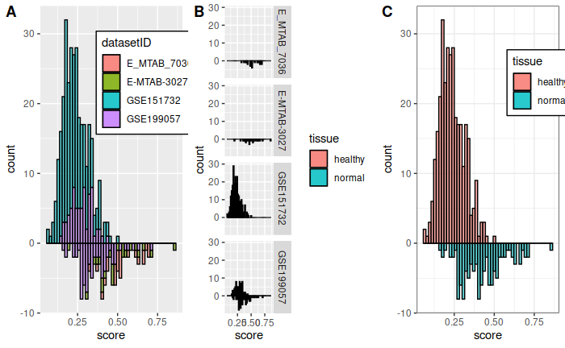

```r
          # predict the results on test
          tmp = predict(tm, as.matrix(d_test_res),type="response",newoffset = d_test_class)

plot_ds = as.data.frame(cbind(data_test$datasetID,data_test$sampleID,tmp,data_test$tissue))
colnames(plot_ds) = c("datasetID","sampleID","score","tissue")
plot_ds$score = as.numeric(plot_ds$score)
plot_a = ggplot() +
    geom_histogram(data = plot_ds[plot_ds$tissue == "normal",], aes(y = -(..count..), x = score, fill = datasetID), col = "black", alpha=.6,bins = 50, position = "stack") +
    geom_histogram(data = plot_ds[plot_ds$tissue == "healthy",], aes(y = ..count.., x = score, fill = datasetID), col = "black", alpha=.6,bins = 50, position = "stack") +
  theme(legend.position = c(0.75, 0.75),
        legend.background = element_rect(fill = "white", color = "black")) +
      labs(#title = "Four datasets, by dataset",
          x = "score",
          y = "count")
#ggsave(filename = "./your/path/clasifier_hist_all_dataset.png",plot = plot_a,width = 12,units = "in")
plot_b =  ggplot() +
    geom_histogram(data = plot_ds[plot_ds$tissue == "normal",], aes(y = -(..count..), x = score, fill = tissue), col = "black", alpha=.6,bins = 50, position = "identity") +
    geom_histogram(data = plot_ds[plot_ds$tissue == "healthy",], aes(y = ..count.., x = score, fill = tissue), col = "black", alpha=.6,bins = 50, position = "identity") +
  facet_grid("datasetID") +
      labs(#title = "By dataset",
          x = "score",
          y = "count")
#ggsave(filename = "./your/path/clasifier_hist_by_dataset.png",plot = plot_b,width = 12,units = "in")

plot_c = ggplot() +
    geom_histogram(data = plot_ds[plot_ds$tissue == "normal",], aes(y = -(..count..), x = score, fill = tissue), col = "black", alpha=.6,bins = 50, position = "identity") +
    geom_histogram(data = plot_ds[plot_ds$tissue == "healthy",], aes(y = ..count.., x = score, fill = tissue), col = "black", alpha=.6,bins = 50, position = "identity") +
  theme_bw() +
  theme(legend.position = c(0.87, 0.75),
        legend.background = element_rect(fill = "white", color = "black")) +
      labs(#title = "Four datasets, by tissue",
          x = "score",
          y = "count")
#ggsave(filename = "./results/clasifier_hist_by_tissue.png",plot = plot_c,width = 12,units = "in")

ggarrange(plot_a,plot_b,plot_c,ncol = 3,labels = c("A","B","C"))
```

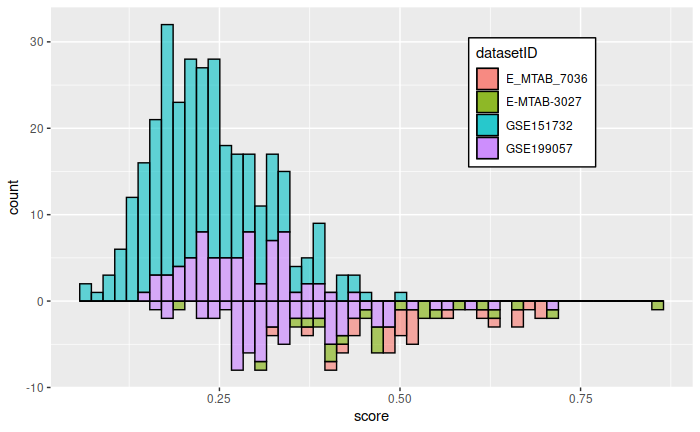

```r
          roc_res = roc.curve(scores.class0 = tmp[d_test_class=="1"],scores.class1 = tmp[d_test_class=="0"])
          pr_res = pr.curve(scores.class0 = tmp[d_test_class=="1"],scores.class1 = tmp[d_test_class=="0"])

plot_a
```

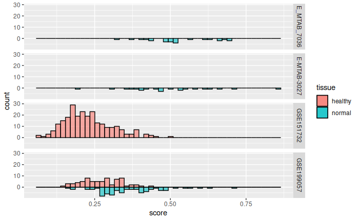

```r
plot_b
```

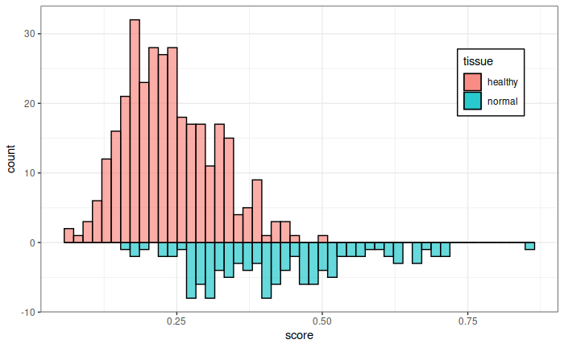

```r
plot_c
```

### Some extra plots

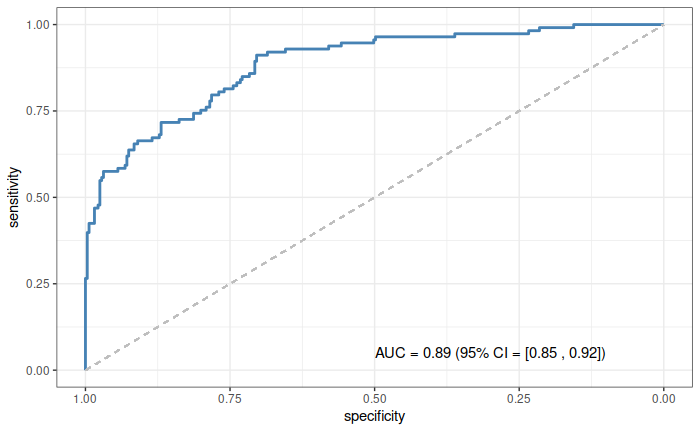

```r
################################
###   ROC plot
################################
library(pROC)
#define object to plot and calculate AUC
rocobj <- pROC::roc(data_test$tissue,tmp[,1])
auc = pROC::auc(rocobj)
ci <- ci.auc(rocobj)
ci_l <- round(ci[1], 2)
ci_u <- round(ci[3], 2)

legend_text <- paste0(
    "AUC = ", round(auc, 2), " (95% CI = [", ci_l, " , ", ci_u, "])")

plot_roc = ggroc(rocobj, colour = 'steelblue',size=1) +
  geom_segment(aes(x = 1, xend = 0, y = 0, yend = 1), color = "grey", linetype = "dashed") +
  theme_bw() +
  annotate("text", x = 0.3, y = 0.05, label = legend_text)

plot_roc
```

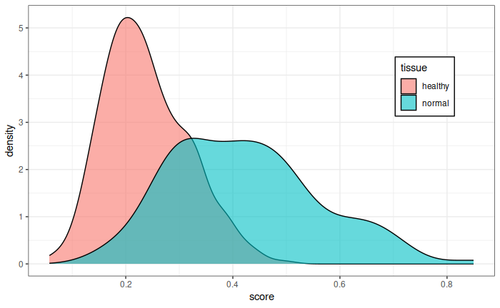

```r
########################
#### Density plot
#########################

library(ggplot2)
density_plot = ggplot() +
    geom_density(data = plot_ds, aes(x=score, fill=tissue),alpha=.6) + theme_bw() +
  theme(legend.position = c(0.85, 0.7),legend.background = element_rect(fill = "white", color = "black"))

density_plot
```

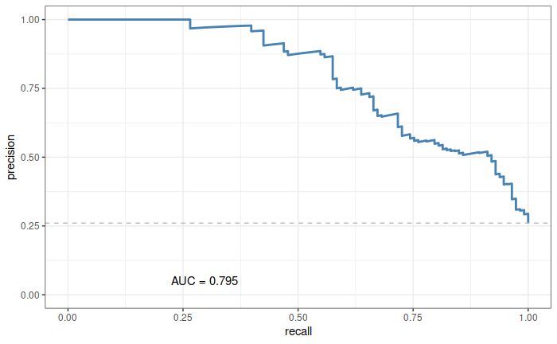

```r
#################################################################
### PR curve - no confidence interval - labels were done manually
#################################################################

library(precrec)
pr_curve_data = evalmod(scores = tmp,labels = data_test$tissue)
pr_curve_ds = as.data.frame(cbind(pr_curve_data$prcs[[1]]$x,pr_curve_data$prcs[[1]]$y))
colnames(pr_curve_ds) = c("recall","precision")
pr_curve_ds$recall=as.numeric(pr_curve_ds$recall)
pr_curve_ds$precision=as.numeric(pr_curve_ds$precision)

y_val = min(pr_curve_ds$precision)
legend_text_pr = "AUC = 0.795 "
plot_pr = ggplot(data = pr_curve_ds, aes(x = recall, y = precision)) +
  geom_path(colour = 'steelblue',size=1) +
  geom_hline(yintercept = y_val, x=0, xend=1, color = "grey", linetype = "dashed") +
      expand_limits(y=0) +
  theme_bw()+
  annotate("text", x = 0.3, y = 0.05, label = legend_text_pr)
plot_pr
```